# Housing Analysis

## Table of Contents

- Introduction
- Load Libraries
- Exploratory Data Analysis
  - SalePrice
  - Numeric Variables
    - OverallQual
    - GrLivArea
    - GarageCars
- Missing Data
  - PoolQC
  - MiscFeature
  - Alley
  - Fence
  - Fireplace
  - Lot
  - Garage
  - Basement
  - Masonry
  - Electrical
- Preparing remaining variables
  - Converting numeric into categorical
- Revisit Correlations
- Permutation Importance
- Feature Engineering
- Data Preparation for Model
- Lasso Regression Model
- XGBoost Model
- Average Predictions

## Introduction

In this project, we look at a data set with 79 variables on homes in Ames, Iowa. Then, we use Machine Learning to predict home prices.

## Load Libraries

```r
library(knitr)
library(ggplot2)
library(plyr)
library(dplyr)
library(corrplot)
library(caret)
library(gridExtra)
library(scales)
library(Rmisc)
library(ggrepel)
library(randomForest)
library(psych)
library(xgboost)
library(missForest)
library(mice)
library(DALEX)
```

## Read in CSV file

```r
test <- read.csv("D:/Coding/R for Data Science/test_house.csv", stringsAsFactors = F)
train <- read.csv("D:/Coding/R for Data Science/train_house.csv", stringsAsFactors = F)
```

## Exploratory Data Analysis

```r
dim(train)
```

```
[1] 1460   81
```

Dimensions of the train data set: 1460 rows and 81 columns.

```r
str(train)
```

```
'data.frame':   1460 obs. of  81 variables:
 $ Id           : int  1 2 3 4 5 6 7 8 9 10 ...
 $ MSSubClass   : int  60 20 60 70 60 50 20 60 50 190 ...
 $ MSZoning     : chr  "RL" "RL" "RL" "RL" ...
 $ LotFrontage  : int  65 80 68 60 84 85 75 NA 51 50 ...
 $ LotArea      : int  8450 9600 11250 9550 14260 14115 10084 10382 6120 7420 ...
 $ Street       : chr  "Pave" "Pave" "Pave" "Pave" ...
 $ Alley        : chr  NA NA NA NA ...
 $ LotShape     : chr  "Reg" "Reg" "IR1" "IR1" ...
 $ LandContour  : chr  "Lvl" "Lvl" "Lvl" "Lvl" ...
 $ Utilities    : chr  "AllPub" "AllPub" "AllPub" "AllPub" ...
 $ LotConfig    : chr  "Inside" "FR2" "Inside" "Corner" ...
 $ LandSlope    : chr  "Gtl" "Gtl" "Gtl" "Gtl" ...
 $ Neighborhood : chr  "CollgCr" "Veenker" "CollgCr" "Crawfor" ...
 $ Condition1   : chr  "Norm" "Feedr" "Norm" "Norm" ...
```

[output cut: 67 more lines]

Structure of the first 10 columns. Let’s remove the Id so it doesn’t affect our analysis later.

```r
train$Id <- NULL
test$Id <- NULL
```

```r
test$SalePrice <- NA
all <- rbind(train, test)
dim(all)
```

```
[1] 2919   80
```

### SalePrice

```r
summary(all$SalePrice)
```

```
   Min. 1st Qu.  Median    Mean 3rd Qu.    Max.    NA's
  34900  129975  163000  180921  214000  755000    1459
```

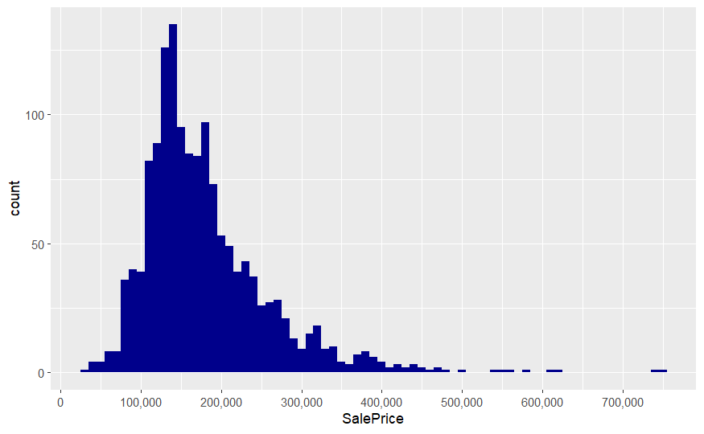

```r
ggplot(data=all[!is.na(all$SalePrice),], aes(x=SalePrice)) +
        geom_histogram(fill="darkblue", binwidth = 10000) +
        scale_x_continuous(breaks= seq(0, 800000, by=100000), labels = comma)
```

The SalePrice is normal distributed but right skewed.

### Numeric Variables

There are a lot of variables in the data set. Let’s use correlational analysis against the SalePrice to see if any variables have high correlation.

```r
numericVars <- which(sapply(all, is.numeric)) #index vector numeric variables
numericVarNames <- names(numericVars) #saving names vector for use later on
cat('There are', length(numericVars), 'numeric variables')
```

```
There are 37 numeric variables
```

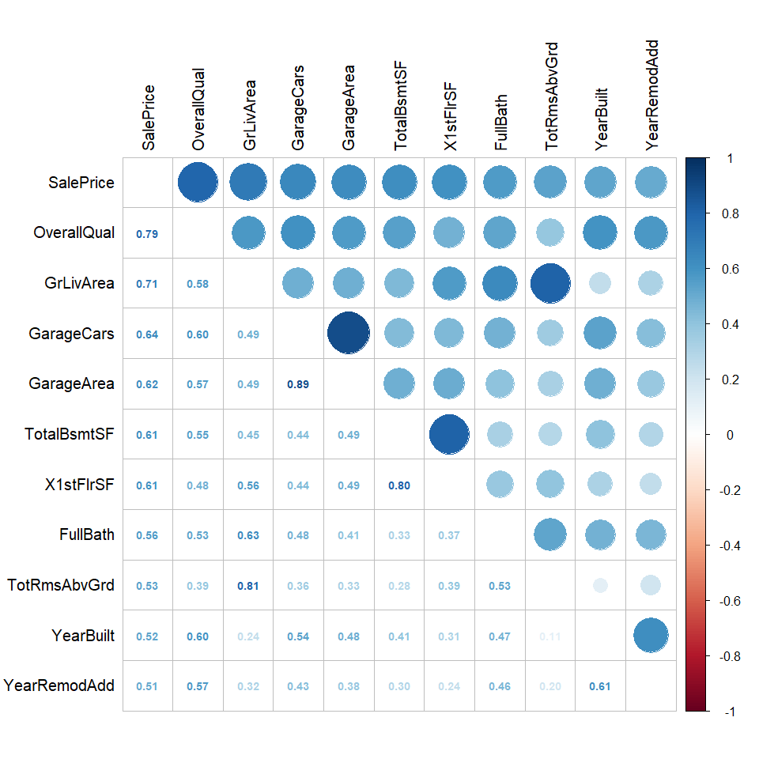

```r
all_numVar <- all[, numericVars]
cor_numVar <- cor(all_numVar, use="pairwise.complete.obs") #correlations of all numeric variables

#sort on decreasing correlations with SalePrice
cor_sorted <- as.matrix(sort(cor_numVar[,'SalePrice'], decreasing = TRUE))

#select only high correlations
CorHigh <- names(which(apply(cor_sorted, 1, function(x) abs(x)>0.5)))
cor_numVar <- cor_numVar[CorHigh, CorHigh]

corrplot.mixed(cor_numVar, tl.col="black", tl.pos = "lt", number.cex=0.7)
```

We can see that OverallQual and GrLivArea(area of the home that is not the basement) is highly correlated with the SalePrice.

Some of the features are also correlated with one another - ie GarageCars and GarageArea (not surprising). We may consider excluding a few of these features with highly correlation to reduce dimensionality and potential overfitting in our model later.

Let’s dive a bit further into some of these features that are highly correlated with SalePrice.

#### OverallQual

OverallQual is on a ten-point scale, with 10 being the highest rated (very excellent).

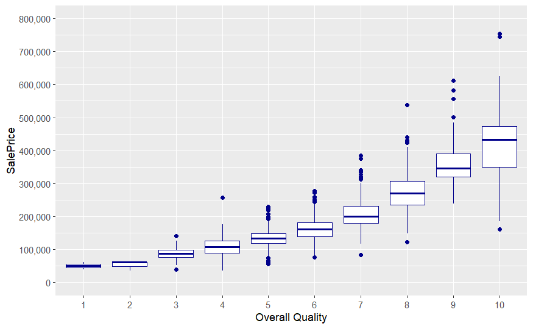

```r
ggplot(data=all[!is.na(all$SalePrice),], aes(x=factor(OverallQual), y=SalePrice))+
        geom_boxplot(col='darkblue') + labs(x='Overall Quality') +
        scale_y_continuous(breaks= seq(0, 800000, by=100000), labels = comma)+
        coord_cartesian(ylim = c(0, 800000))
```

We see a positive correlation between SalePrice and OverallQual. There are outliers that exceed the 1.5*IQR in many of the OverallQual categories, but they appear to be reasonable outlier housing sale price rather than error, so we won’t be removing them.

#### GrLivArea

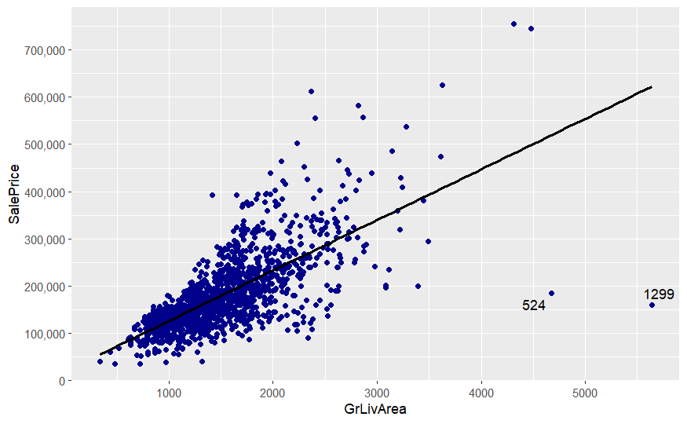

```r
ggplot(data=all[!is.na(all$SalePrice),], aes(x=GrLivArea, y=SalePrice))+
        geom_point(col='darkblue') + geom_smooth(method = "lm", se=FALSE, color="black", aes(group=1)) +
        scale_y_continuous(breaks= seq(0, 800000, by=100000), labels = comma) +
        geom_text_repel(aes(label = ifelse(GrLivArea[!is.na(SalePrice)]>4500, rownames(train), '')))
```

The SalePrice is positively correlated with GrLivArea which is not surprising as the greater the area of the home usually means higher housing prince. We see a few outliers with massive GrLivArea but low housing price (labelled 524 and 1299).

```r
all[c(524, 1299), c(CorHigh)]
```

|  | SalePrice | OverallQual | GrLivArea | GarageCars | GarageArea | TotalBsmtSF | X1stFlrSF | FullBath | TotRmsAbvGrd | YearBuilt | YearRemodAdd |
| --- | --- | --- | --- | --- | --- | --- | --- | --- | --- | --- | --- |
| 524 | 184750 | 10 | 4676 | 3 | 884 | 3138 | 3138 | 3 | 11 | 2007 | 2008 |
| 1299 | 160000 | 10 | 5642 | 2 | 1418 | 6110 | 4692 | 2 | 12 | 2008 | 2008 |

Looking at the two outliers more closely, we see that their OverallQual are both 10. Nothing in particular explains why the SalePrice could be low.

#### GarageCars

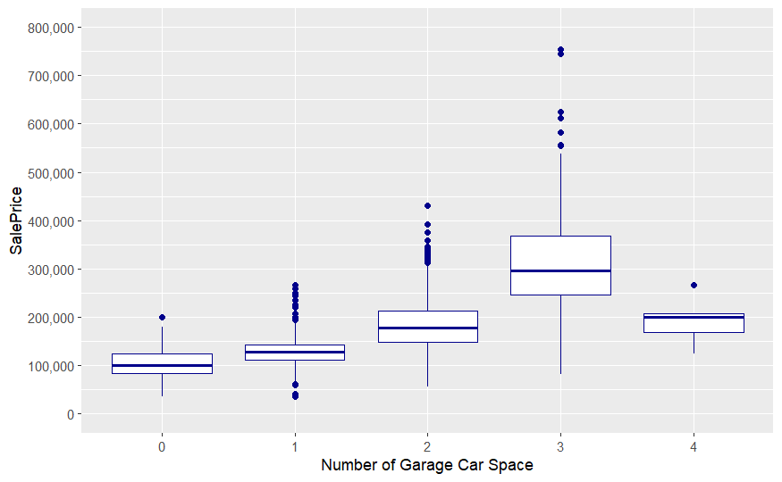

```r
ggplot(data=all[!is.na(all$SalePrice),], aes(x=factor(GarageCars), y=SalePrice))+
        geom_boxplot(col='darkblue') + labs(x='Number of Garage Car Space') +
        scale_y_continuous(breaks= seq(0, 800000, by=100000), labels = comma) +
        coord_cartesian(ylim = c(0, 800000))
```

There is a positive correlation between SalePrice and GarageCars until GarageCars exceeds 3.GarageCars may be just as highly correlated as OverallQual up to 3.

## Missing Data

```r
NA_columns <- which(colSums(is.na(all)) > 0)
sort(colSums(is.na(all[NA_columns])), decreasing=TRUE)
```

```
      PoolQC  MiscFeature        Alley        Fence    SalePrice  FireplaceQu  LotFrontage  GarageYrBlt GarageFinish
        2909         2814         2721         2348         1459         1420          486          159          159
  GarageQual   GarageCond   GarageType     BsmtCond BsmtExposure     BsmtQual BsmtFinType2 BsmtFinType1   MasVnrType
         159          159          157           82           82           81           80           79           24
  MasVnrArea     MSZoning    Utilities BsmtFullBath BsmtHalfBath   Functional  Exterior1st  Exterior2nd   BsmtFinSF1
          23            4            2            2            2            2            1            1            1
  BsmtFinSF2    BsmtUnfSF  TotalBsmtSF   Electrical  KitchenQual   GarageCars   GarageArea     SaleType
           1            1            1            1            1            1            1            1
```

## Imputing Missing Data

We will go through each of the features and clean up the missing data.

#### PoolQC

PoolQC: Pool quality

```
   Ex   Excellent
   Gd   Good
   TA   Average/Typical
   Fa   Fair
   NA   No Pool
```

NA is already explained in the variable description, so we will fix the data so it reflects ‘No Pool’. We will also change the values to numeric to reflect the ordinal values.

```r
all$PoolQC[is.na(all$PoolQC)] <- 'None'
Pool_qualities <- c('None' = 0, 'Po' = 1, 'Fa' = 2, 'TA' = 3, 'Gd' = 4, 'Ex' = 5)
all$PoolQC<-as.integer(revalue(all$PoolQC, Pool_qualities))
table(all$PoolQC)
```

```
   0    2    4    5
2909    2    4    4
```

#### MiscFeature

Miscellaneous Features:

```
   Elev Elevator
   Gar2 2nd Garage (if not described in garage section)
   Othr Other
   Shed Shed (over 100 SF)
   TenC Tennis Court
   NA   None
```

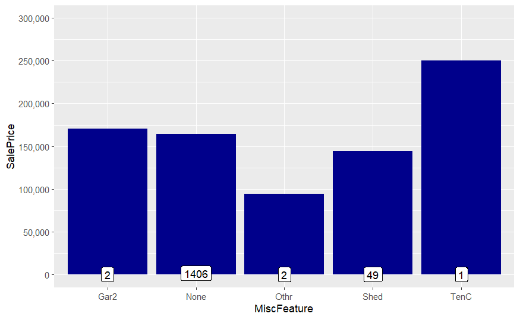

```r
all$MiscFeature[is.na(all$MiscFeature)] <- 'None'
all$MiscFeature <- as.factor(all$MiscFeature)

ggplot(all[!is.na(all$SalePrice),], aes(x=MiscFeature, y=SalePrice)) +
        geom_bar(stat='summary', fun = 'median', fill='darkblue') +
        scale_y_continuous(breaks= seq(0, 300000, by=50000), labels = comma) +
        geom_label(stat = "count", aes(label = after_stat(count), y = after_stat(count))) +
        coord_cartesian(ylim = c(0, 300000))
```

No obvious pattern here to explain correlation with SalePrice. We may exclude this category altogether during our feature selection.

#### Alley

Alley values:

```
Grvl Gravel
Pave Paved
NA   No alley access
```

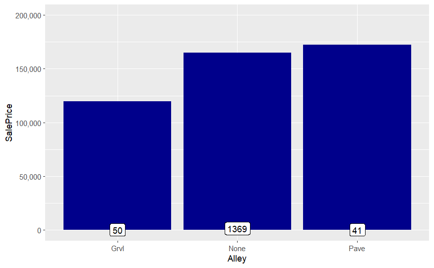

```r
all$Alley[is.na(all$Alley)] <- 'None'
all$Alley <- as.factor(all$Alley)

ggplot(all[!is.na(all$SalePrice),], aes(x=Alley, y=SalePrice)) +
        geom_bar(stat='summary', fun = 'median', fill='darkblue')+
        scale_y_continuous(breaks= seq(0, 200000, by=50000), labels = comma) +
        geom_label(stat = "count", aes(label = after_stat(count), y = after_stat(count))) +
        coord_cartesian(ylim = c(0, 200000))
```

Paved alley tends to be higher in SalePrice than gravel alley.

#### Fence

Values:

```
GdPrv    Good Privacy
MnPrv    Minimum Privacy
GdWo Good Wood
MnWw Minimum Wood/Wire
NA   No Fence
```

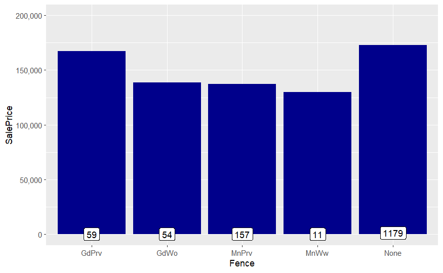

```r
all$Fence[is.na(all$Fence)] <- 'None'

ggplot(all[!is.na(all$SalePrice),], aes(x=Fence, y=SalePrice)) +
        geom_bar(stat='summary', fun = 'median', fill='darkblue')+
        scale_y_continuous(breaks= seq(0, 200000, by=50000), labels = comma) +
        geom_label(stat = "count", aes(label = after_stat(count), y = after_stat(count))) +
        coord_cartesian(ylim = c(0, 200000))
```

No particular pattern here except Good Privacy > Minimum Privacy and Good Wood > Minimum wood/wire, but No Fence is actually higher in SalePrice, which is conflicting. It will be difficult to apply this feature as we can’t discern how privacy values are related to fencing.

```r
all$Fence <- as.factor(all$Fence)
```

#### Fireplace

FireplaceQu values:

```
Ex   Excellent - Exceptional Masonry Fireplace
Gd   Good - Masonry Fireplace in main level
TA   Average - Prefabricated Fireplace in main living area or Masonry Fireplace in basement
Fa   Fair - Prefabricated Fireplace in basement
Po   Poor - Ben Franklin Stove
NA   No Fireplace
```

```r
sum(is.na(all$FireplaceQu)) == sum(all$Fireplaces == 0) #FireplaceQu = No Fireplace is equivalent to number of fireplace = 0
```

```
[1] TRUE
```

We can replace ‘NA’ for FireplaceQu with ‘None’

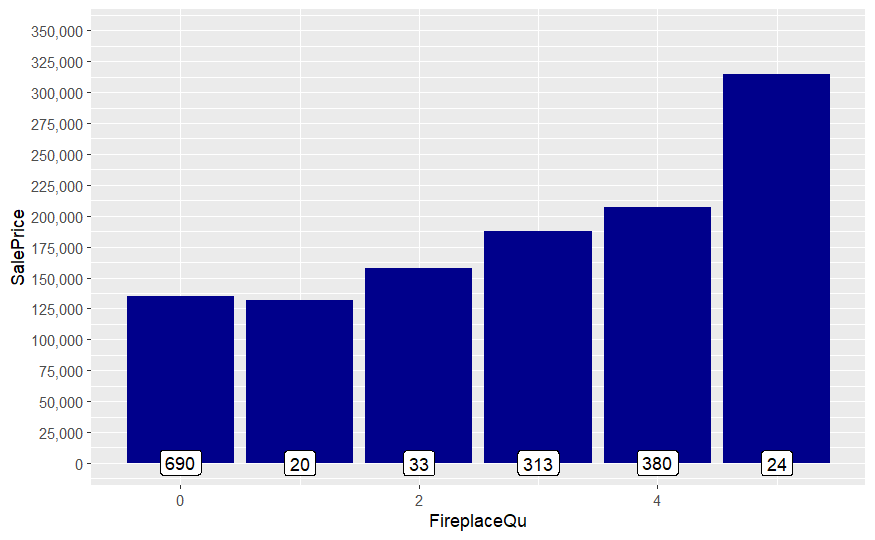

```r
all$FireplaceQu[is.na(all$FireplaceQu)] <- 'None'
fireplace_qualities <- c('None' = 0, 'Po' = 1, 'Fa' = 2, 'TA' = 3, 'Gd' = 4, 'Ex' = 5)
all$FireplaceQu<-as.integer(revalue(all$FireplaceQu, fireplace_qualities))

ggplot(all[!is.na(all$SalePrice),], aes(x=FireplaceQu, y=SalePrice)) +
        geom_bar(stat='summary', fun = 'median', fill='darkblue')+
        scale_y_continuous(breaks= seq(0, 350000, by=25000), labels = comma) +
        geom_label(stat = "count", aes(label = after_stat(count), y = after_stat(count))) +
        coord_cartesian(ylim = c(0, 350000))
```

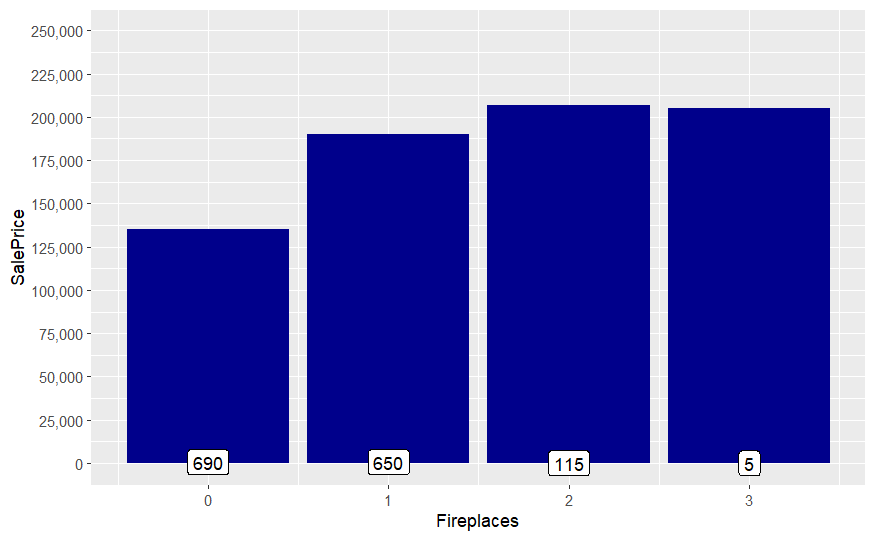

```r
ggplot(all[!is.na(all$SalePrice),], aes(x=Fireplaces, y=SalePrice)) +
        geom_bar(stat='summary', fun = 'median', fill='darkblue')+
        scale_y_continuous(breaks= seq(0, 250000, by=25000), labels = comma) +
        geom_label(stat = "count", aes(label = after_stat(count), y = after_stat(count))) +
        coord_cartesian(ylim = c(0, 250000))
```

We can see a positive correlation between Fireplaces and FireplaceQu with SalePrice.

#### Lot

Three variables: LotFrontage, LotShape, LotConfig

```r
colSums(is.na(all[c('LotFrontage','LotShape','LotConfig')]))
```

```
LotFrontage    LotShape   LotConfig
        486           0           0
```

##### LotFrontage

Since we did not detect significant correlation between SalePrice and LotFrontage in our correlation analysis, we will assume the missing values are due to random events. LotFrontage may be related to the neighborhood in which the home is situated and we can assume the LotFrontage will be similar in homes in the same neighborhood. We can impute based on the median LotFrontage in each neighborhood. We will use missForest() to help us do that.

```r
subset_data <- all[, c("LotFrontage", "Neighborhood")]

# Perform one-hot encoding on the 'Neighborhood' column
encoded_df <- model.matrix(~ Neighborhood - 1, data = subset_data)

# Convert the matrix to a dataframe
encoded_df <- as.data.frame(encoded_df)

# Combine the one-hot encoded neighborhood with the original 'LotFrontage' column
encoded_df <- cbind(subset_data$LotFrontage, encoded_df)

# Perform imputation using missForest
imputed_result <- missForest(encoded_df)

# Access the imputed values from the result object
imputed_values <- as.data.frame(imputed_result$ximp)

# Set imputed values
all$LotFrontage <- imputed_values[, c('subset_data$LotFrontage')]
```

##### LotShape

Values:

```
Reg  Regular
IR1  Slightly irregular
IR2  Moderately Irregular
IR3  Irregular
```

These values seem ordinal.

```r
# Convert to numeric
all$LotShape<-as.integer(revalue(all$LotShape, c('IR3'=0, 'IR2'=1, 'IR1'=2, 'Reg'=3)))
table(all$LotShape)
```

```
   0    1    2    3
  16   76  968 1859
```

##### LotConfig

Values:

```
Inside   Inside lot
Corner   Corner lot
CulDSac  Cul-de-sac
FR2  Frontage on 2 sides of property
FR3  Frontage on 3 sides of property
```

These are nominal. We will just convert them to factors.

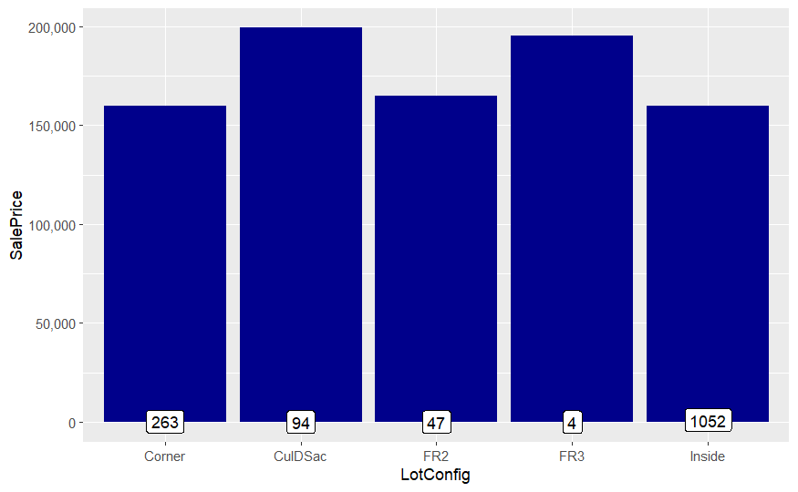

```r
all$LotConfig <- as.factor(all$LotConfig)

ggplot(all[!is.na(all$SalePrice),], aes(x=LotConfig, y=SalePrice)) +
        geom_bar(stat='summary', fun = "median", fill='darkblue')+
        scale_y_continuous(breaks= seq(0, 200000, by=50000), labels = comma) +
        geom_label(stat = "count", aes(label = ..count.., y = ..count..))
```

No specific pattern here.

#### Garage

```r
all[is.na(all$GarageType), c('GarageCars','GarageArea', 'GarageYrBlt', 'GarageType', 'GarageCond', 'GarageQual', 'GarageFinish')]
```

|  | GarageCars | GarageArea | GarageYrBlt | GarageType | GarageCond | GarageQual | GarageFinish |
| --- | --- | --- | --- | --- | --- | --- | --- |
| 40 | 0 | 0 | NA | NA | NA | NA | NA |
| 49 | 0 | 0 | NA | NA | NA | NA | NA |
| 79 | 0 | 0 | NA | NA | NA | NA | NA |
| 89 | 0 | 0 | NA | NA | NA | NA | NA |
| 90 | 0 | 0 | NA | NA | NA | NA | NA |
| 100 | 0 | 0 | NA | NA | NA | NA | NA |
| 109 | 0 | 0 | NA | NA | NA | NA | NA |
| 126 | 0 | 0 | NA | NA | NA | NA | NA |
| 128 | 0 | 0 | NA | NA | NA | NA | NA |
| 141 | 0 | 0 | NA | NA | NA | NA | NA |

[output cut: 147 more lines]

```r
garage <- c('GarageCars','GarageArea', 'GarageYrBlt', 'GarageType', 'GarageCond', 'GarageQual', 'GarageFinish')
for (i in garage){
  all[[i]] <- 'None'
}
```

##### GarageType

Values:

```
2Types   More than one type of garage
Attchd   Attached to home
Basment  Basement Garage
BuiltIn  Built-In (Garage part of house - typically has room above garage)
CarPort  Car Port
Detchd   Detached from home
NA   No Garage
```

Convert these to nominal factors.

```r
all$GarageType <- as.factor(all$GarageType)
```

##### GarageCond

Values:

```
Ex   Excellent
Gd   Good
TA   Typical/Average
Fa   Fair
Po   Poor
NA   No Garage
```

```r
qualities <- c('None' = 0, 'Po' = 1, 'Fa' = 2, 'TA' = 3, 'Gd' = 4, 'Ex' = 5)
all$GarageCond<-as.integer(revalue(all$GarageCond, qualities))
```

##### GarageQual

Values:

```
Ex   Excellent
Gd   Good
TA   Typical/Average
Fa   Fair
Po   Poor
NA   No Garage
```

```r
all$GarageQual<-as.integer(revalue(all$GarageQual, qualities))
```

##### GarageFinish

Values:

```
Fin  Finished
RFn  Rough Finished
Unf  Unfinished
NA   No Garage
```

```r
Finish <- c('None'=0, 'Unf'=1, 'RFn'=2, 'Fin'=3)
all$GarageFinish<-as.integer(revalue(all$GarageFinish, Finish))
```

#### Basement

There are 11 variables related to the basement. ‘BsmtQual’, ‘BsmtCond’, ‘BsmtExposure’, ‘BsmtFinType1’, ‘BsmtFinType2’ have similar number of missing values. Remaining variables: ‘BsmtFullBath’, ‘BsmtHalfBath’, ‘BsmtFinSF1’, ‘BsmtFinSF2’, ‘BsmtUnfSF’, ‘TotalBsmtSF’

```r
all[!is.na(all$BsmtFinType1) & (is.na(all$BsmtCond)|is.na(all$BsmtQual)|is.na(all$BsmtExposure)|is.na(all$BsmtFinType2)), c('BsmtQual', 'BsmtCond', 'BsmtExposure', 'BsmtFinType1', 'BsmtFinType2')]
```

|  | BsmtQual | BsmtCond | BsmtExposure | BsmtFinType1 | BsmtFinType2 |
| --- | --- | --- | --- | --- | --- |
| 333 | Gd | TA | No | GLQ | NA |
| 949 | Gd | TA | NA | Unf | Unf |
| 1488 | Gd | TA | NA | Unf | Unf |
| 2041 | Gd | NA | Mn | GLQ | Rec |
| 2186 | TA | NA | No | BLQ | Unf |
| 2218 | NA | Fa | No | Unf | Unf |
| 2219 | NA | TA | No | Unf | Unf |
| 2349 | Gd | TA | NA | Unf | Unf |
| 2525 | TA | NA | Av | ALQ | Unf |

Except for the above the rest seem to be consistent with not having a basement.

```r
#Imputing modes.
all$BsmtFinType2[333] <- names(sort(-table(all$BsmtFinType2)))[1]
all$BsmtExposure[c(949, 1488, 2349)] <- names(sort(-table(all$BsmtExposure)))[1]
all$BsmtCond[c(2041, 2186, 2525)] <- names(sort(-table(all$BsmtCond)))[1]
all$BsmtQual[c(2218, 2219)] <- names(sort(-table(all$BsmtQual)))[1]
```

##### BsmtQual

```
Ex   Excellent (100+ inches)
Gd   Good (90-99 inches)
TA   Typical (80-89 inches)
Fa   Fair (70-79 inches)
Po   Poor (<70 inches
NA   No Basement
```

```r
all$BsmtQual[is.na(all$BsmtQual)] <- 'None'
all$BsmtQual<-as.integer(revalue(all$BsmtQual, qualities))
table(all$BsmtQual)
```

```
   0    2    3    4    5
  79   88 1285 1209  258
```

##### BsmtCond

```
Ex   Excellent
Gd   Good
TA   Typical - slight dampness allowed
Fa   Fair - dampness or some cracking or settling
Po   Poor - Severe cracking, settling, or wetness
NA   No Basement
```

```r
all$BsmtCond[is.na(all$BsmtCond)] <- 'None'
all$BsmtCond<-as.integer(revalue(all$BsmtCond, qualities))
table(all$BsmtCond)
```

```
   0    1    2    3    4
  79    5  104 2609  122
```

##### BsmtFinType1

```
GLQ  Good Living Quarters
ALQ  Average Living Quarters
BLQ  Below Average Living Quarters
Rec  Average Rec Room
LwQ  Low Quality
Unf  Unfinshed
NA   No Basement
```

```r
all$BsmtFinType1[is.na(all$BsmtFinType1)] <- 'None'
FinType <- c('None'=0, 'Unf'=1, 'LwQ'=2, 'Rec'=3, 'BLQ'=4, 'ALQ'=5, 'GLQ'=6)

all$BsmtFinType1<-as.integer(revalue(all$BsmtFinType1, FinType))
table(all$BsmtFinType1)
```

```
  0   1   2   3   4   5   6
 79 851 154 288 269 429 849
```

##### BsmtFinType2

```
GLQ  Good Living Quarters
ALQ  Average Living Quarters
BLQ  Below Average Living Quarters
Rec  Average Rec Room
LwQ  Low Quality
Unf  Unfinshed
NA   No Basement
```

```r
all$BsmtFinType2[is.na(all$BsmtFinType2)] <- 'None'
FinType <- c('None'=0, 'Unf'=1, 'LwQ'=2, 'Rec'=3, 'BLQ'=4, 'ALQ'=5, 'GLQ'=6)

all$BsmtFinType2<-as.integer(revalue(all$BsmtFinType2, FinType))
table(all$BsmtFinType2)
```

```
   0    1    2    3    4    5    6
  79 2494   87  105   68   52   34
```

##### BsmtExposure

```
Gd   Good Exposure
Av   Average Exposure (split levels or foyers typically score average or above)
Mn   Mimimum Exposure
No   No Exposure
NA   No Basement
```

```r
all$BsmtExposure[is.na(all$BsmtExposure)] <- 'None'
Exposure <- c('None'=0, 'No'=1, 'Mn'=2, 'Av'=3, 'Gd'=4)

all$BsmtExposure<-as.integer(revalue(all$BsmtExposure, Exposure))
table(all$BsmtExposure)
```

```
   0    1    2    3    4
  79 1907  239  418  276
```

##### Remaining

```r
all$BsmtFinSF1[is.na(all$BsmtFinSF1)] <-0
all$BsmtFinSF2[is.na(all$BsmtFinSF2)] <-0
all$BsmtUnfSF[is.na(all$BsmtUnfSF)] <-0
all$TotalBsmtSF[is.na(all$TotalBsmtSF)] <-0
all$BsmtFullBath[is.na(all$BsmtFullBath)] <-0
all$BsmtHalfBath[is.na(all$BsmtHalfBath)] <-0
```

#### Masonry

```r
all[is.na(all$MasVnrType) & is.na(all$MasVnrArea), c('MasVnrType', 'MasVnrArea')]
```

|  | MasVnrType | MasVnrArea |
| --- | --- | --- |
| 235 | NA | NA |
| 530 | NA | NA |
| 651 | NA | NA |
| 937 | NA | NA |
| 974 | NA | NA |
| 978 | NA | NA |
| 1244 | NA | NA |
| 1279 | NA | NA |
| 1692 | NA | NA |
| 1707 | NA | NA |

[output cut: 13 more lines]

##### MasVnrType

Values:

```
BrkCmn   Brick Common
BrkFace  Brick Face
CBlock   Cinder Block
None None
Stone    Stone
```

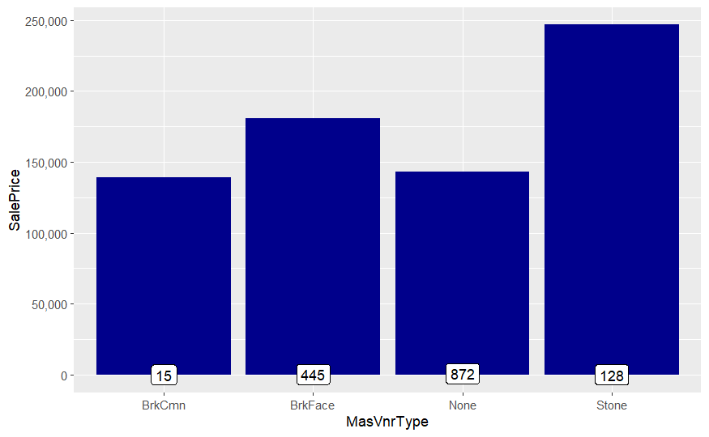

```r
all$MasVnrType[is.na(all$MasVnrType)] <- 'None'

ggplot(all[!is.na(all$SalePrice),], aes(x=MasVnrType, y=SalePrice)) +
        geom_bar(stat='summary', fun = "median", fill='darkblue')+
        scale_y_continuous(breaks= seq(0, 250000, by=50000), labels = comma) +
        geom_label(stat = "count", aes(label = ..count.., y = ..count..))
```

BrkFace and Stone appears to be higher in SalePrice compared to BrkCmn and None. We will introduce ordinality by combining BrkCmn and None and ranking up to Stone (BrkCmn/None -> BrkFace -> Stone).

```r
Masonry <- c('None'=0, 'BrkCmn'=0, 'BrkFace'=1, 'Stone'=2)
all$MasVnrType<-as.integer(revalue(all$MasVnrType, Masonry))
table(all$MasVnrType)
```

```
   0    1    2
1791  879  249
```

##### MasVnrArea

Since we set the MasVnrType ‘NA’ to ‘None’, the area will be 0.

```r
all$MasVnrArea[is.na(all$MasVnrArea)] <- 0
```

#### Electrical

Values:

```
SBrkr    Standard Circuit Breakers & Romex
FuseA    Fuse Box over 60 AMP and all Romex wiring (Average)
FuseF    60 AMP Fuse Box and mostly Romex wiring (Fair)
FuseP    60 AMP Fuse Box and mostly knob & tube wiring (poor)
Mix  Mixed
```

```r
table(all$Electrical)
```

```
FuseA FuseF FuseP   Mix SBrkr
  188    50     8     1  2671
```

```r
all$Electrical <- as.factor(all$Electrical)
```

```r
all[is.na(all$Electrical), c('SalePrice')]
```

```
[1] 167500
```

There is only one null value for electrical.

```r
subset_data <- all[, c("SalePrice", "Electrical")]

# Perform imputation using mice
imputed_result <- mice(subset_data, method='pmm', m=5)
# Access the imputed values from the result object
imputed_values <- complete(imputed_result)

#Check imputed
imputed_values[imputed_values$SalePrice == 167500, c('Electrical','SalePrice')]
```

|  | Electrical | SalePrice |
| --- | --- | --- |
| 975 | SBrkr | 167500 |
| 1027 | SBrkr | 167500 |
| 1380 | SBrkr | 167500 |

```r
# Set imputed values
all$Electrical <- imputed_values[, c('Electrical')]
```

## Preparing remaining variables

#### MS Zoning

Values:

```
A    Agriculture
C    Commercial
FV   Floating Village Residential
I    Industrial
RH   Residential High Density
RL   Residential Low Density
RP   Residential Low Density Park
RM   Residential Medium Density
```

```r
all$MSZoning[is.na(all$MSZoning)] <- names(sort(-table(all$MSZoning)))[1]
all$MSZoning <- as.factor(all$MSZoning)
```

#### Kitchen

##### KitchenQual

Values:

```
Ex   Excellent
Gd   Good
TA   Typical/Average
Fa   Fair
Po   Poor
```

```r
all$KitchenQual[is.na(all$KitchenQual)] <- 'TA' #replace with most common value
all$KitchenQual<-as.integer(revalue(all$KitchenQual, qualities))
```

##### KitchenAbvGr

```r
table(all$KitchenAbvGr)
```

```
   0    1    2    3
   3 2785  129    2
```

Nothing to prepare here.

#### Utilities

```r
table(all$Utilities)
```

```
AllPub NoSeWa
  2916      1
```

Since most of the homes are AllPub, it is not very useful as a predictor / feature.

```r
all$Utilities <- NULL
```

#### Home Functionalities

Values:

```
Typ  Typical Functionality
Min1 Minor Deductions 1
Min2 Minor Deductions 2
Mod  Moderate Deductions
Maj1 Major Deductions 1
Maj2 Major Deductions 2
Sev  Severely Damaged
Sal  Salvage only
```

```r
all$Functional[is.na(all$Functional)] <- names(sort(-table(all$Functional)))[1]
all$Functional <- as.integer(revalue(all$Functional, c('Sal'=0, 'Sev'=1, 'Maj2'=2, 'Maj1'=3, 'Mod'=4, 'Min2'=5, 'Min1'=6, 'Typ'=7)))
table(all$Functional)
```

```
   1    2    3    4    5    6    7
   2    9   19   35   70   65 2719
```

#### Exterior

##### Exterior1st

Values:

```
AsbShng  Asbestos Shingles
AsphShn  Asphalt Shingles
BrkComm  Brick Common
BrkFace  Brick Face
CBlock   Cinder Block
CemntBd  Cement Board
HdBoard  Hard Board
ImStucc  Imitation Stucco
MetalSd  Metal Siding
Other    Other
Plywood  Plywood
PreCast  PreCast
Stone    Stone
Stucco   Stucco
VinylSd  Vinyl Siding
Wd Sdng  Wood Siding
WdShing  Wood Shingles
```

```r
all$Exterior1st[is.na(all$Exterior1st)] <- names(sort(-table(all$Exterior1st)))[1]
all$Exterior1st <- as.factor(all$Exterior1st)
```

##### Exterior2nd

Values:

```
AsbShng  Asbestos Shingles
AsphShn  Asphalt Shingles
BrkComm  Brick Common
BrkFace  Brick Face
CBlock   Cinder Block
CemntBd  Cement Board
HdBoard  Hard Board
ImStucc  Imitation Stucco
MetalSd  Metal Siding
Other    Other
Plywood  Plywood
PreCast  PreCast
Stone    Stone
Stucco   Stucco
VinylSd  Vinyl Siding
Wd Sdng  Wood Siding
WdShing  Wood Shingles
```

```r
all$Exterior2nd[is.na(all$Exterior2nd)] <- names(sort(-table(all$Exterior2nd)))[1]
all$Exterior2nd <- as.factor(all$Exterior2nd)
```

##### ExterQual

Values:

```
Ex   Excellent
Gd   Good
TA   Average/Typical
Fa   Fair
Po   Poor
```

```r
all$ExterQual<-as.integer(revalue(all$ExterQual, qualities))
```

##### ExterCond

Values:

```
Ex   Excellent
Gd   Good
TA   Average/Typical
Fa   Fair
Po   Poor
```

```r
all$ExterCond<-as.integer(revalue(all$ExterCond, qualities))
```

#### Sale Type and Condition

##### SaleType

Values:

```
WD   Warranty Deed - Conventional
CWD  Warranty Deed - Cash
VWD  Warranty Deed - VA Loan
New  Home just constructed and sold
COD  Court Officer Deed/Estate
Con  Contract 15% Down payment regular terms
ConLw    Contract Low Down payment and low interest
ConLI    Contract Low Interest
ConLD    Contract Low Down
Oth  Other
```

```r
all$SaleType[is.na(all$SaleType)] <- names(sort(-table(all$SaleType)))[1]

all$SaleType <- as.factor(all$SaleType)
```

##### SaleCondition

Values:

```
Normal   Normal Sale
Abnorml  Abnormal Sale -  trade, foreclosure, short sale
AdjLand  Adjoining Land Purchase
Alloca   Allocation - two linked properties with separate deeds, typically condo with a garage unit
Family   Sale between family members
Partial  Home was not completed when last assessed (associated with New Homes)
```

```r
all$SaleCondition <- as.factor(all$SaleCondition)
```

##### Foundation

Values:

```
 BrkTil          Brick & Tile
 CBlock          Cinder Block
 PConc           Poured Contrete
 Slab            Slab
 Stone           Stone
 Wood            Wood
```

```r
all$Foundation <- as.factor(all$Foundation)
```

##### Heating

Values:

```
Floor    Floor Furnace
GasA Gas forced warm air furnace
GasW Gas hot water or steam heat
Grav Gravity furnace
OthW Hot water or steam heat other than gas
Wall Wall furnace
```

```r
all$Heating <- as.factor(all$Heating)
```

##### HeatingQC

Values:

```
Ex   Excellent
Gd   Good
TA   Average/Typical
Fa   Fair
Po   Poor
```

```r
all$HeatingQC <- as.integer(revalue(all$HeatingQC, qualities))
```

##### CentralAir

Values:

```
N    No
Y    Yes
```

```r
all$CentralAir<-as.integer(revalue(all$CentralAir, c('N'=0, 'Y'=1)))
```

##### RoofStyle

Values:

```
Flat Flat
Gable    Gable
Gambrel  Gabrel (Barn)
Hip  Hip
Mansard  Mansard
Shed Shed
```

```r
all$RoofStyle <- as.factor(all$RoofStyle)
```

##### RoofMatl

Values:

```
ClyTile  Clay or Tile
CompShg  Standard (Composite) Shingle
Membran  Membrane
Metal    Metal
Roll Roll
Tar&Grv  Gravel & Tar
WdShake  Wood Shakes
WdShngl  Wood Shingles
```

```r
all$RoofMatl <- as.factor(all$RoofMatl)
```

##### LandContour

Values:

```
Lvl  Near Flat/Level
Bnk  Banked - Quick and significant rise from street grade to building
HLS  Hillside - Significant slope from side to side
Low  Depression
```

```r
all$LandContour <- as.factor(all$LandContour)
```

##### LandSlope

Values:

```
Gtl  Gentle slope
Mod  Moderate Slope
Sev  Severe Slope
```

```r
all$LandSlope <- as.integer(revalue(all$LandSlope, c('Sev'=0, 'Mod'=1, 'Gtl'=2)))
```

##### BldgType

Values:

```
1Fam Single-family Detached
2FmCon   Two-family Conversion; originally built as one-family dwelling
Duplx    Duplex
TwnhsE   Townhouse End Unit
TwnhsI   Townhouse Inside Unit
```

```r
all$BldgType <- as.factor(all$BldgType)
```

##### HouseStyle

Values:

```
1Story   One story
1.5Fin   One and one-half story: 2nd level finished
1.5Unf   One and one-half story: 2nd level unfinished
2Story   Two story
2.5Fin   Two and one-half story: 2nd level finished
2.5Unf   Two and one-half story: 2nd level unfinished
SFoyer   Split Foyer
SLvl Split Level
```

```r
all$HouseStyle <- as.factor(all$HouseStyle)
```

##### Neighborhood

No ordinality.

```r
all$Neighborhood <- as.factor(all$Neighborhood)
```

##### Condition1 and Condition 2

Also ordinality.

```r
all[,c('Condition1','Condition2')] <- lapply(all[,c('Condition1','Condition2')], as.factor)
```

##### Street

Values:

```
Grvl Gravel
Pave Paved
```

```r
all$Street<-as.integer(revalue(all$Street, c('Grvl'=0, 'Pave'=1)))
```

##### PavedDrive

Values:

```
Y    Paved
P    Partial Pavement
N    Dirt/Gravel
```

```r
all$PavedDrive<-as.integer(revalue(all$PavedDrive, c('N'=0, 'P'=1, 'Y'=2)))
```

### Converting numeric into categorical

Some numeric data should be converted into categorical data. - MSSubClass: data present as numeric code but no inherent ordinality or ranking

```
20  1-STORY 1946 & NEWER ALL STYLES
30  1-STORY 1945 & OLDER
40  1-STORY W/FINISHED ATTIC ALL AGES
45  1-1/2 STORY - UNFINISHED ALL AGES
50  1-1/2 STORY FINISHED ALL AGES
60  2-STORY 1946 & NEWER
70  2-STORY 1945 & OLDER
75  2-1/2 STORY ALL AGES
80  SPLIT OR MULTI-LEVEL
85  SPLIT FOYER
90  DUPLEX - ALL STYLES AND AGES
120  1-STORY PUD (Planned Unit Development) - 1946 & NEWER
150  1-1/2 STORY PUD - ALL AGES
160  2-STORY PUD - 1946 & NEWER
180  PUD - MULTILEVEL - INCL SPLIT LEV/FOYER
190  2 FAMILY CONVERSION - ALL STYLES AND AGES
```

```r
all$MSSubClass <- as.factor(all$MSSubClass)

#revalue for better readability
all$MSSubClass<-revalue(all$MSSubClass, c('20'='1 story 1946+', '30'='1 story 1945-', '40'='1 story unf attic', '45'='1,5 story unf', '50'='1,5 story fin', '60'='2 story 1946+', '70'='2 story 1945-', '75'='2,5 story all ages', '80'='split/multi level', '85'='split foyer', '90'='duplex all style/age', '120'='1 story PUD 1946+', '150'='1,5 story PUD all', '160'='2 story PUD 1946+', '180'='PUD multilevel', '190'='2 family conversion'))
```

- MoSold: month sold, convert this to categorical data (factor) instead of int

```r
all$MoSold <- as.factor(all$MoSold)
```

## Revisit Correlations

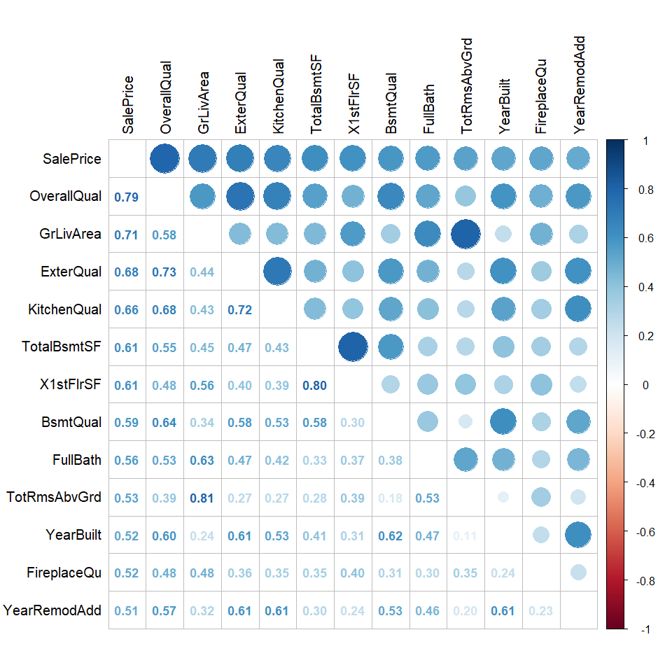

```r
numericVars <- which(sapply(all, is.numeric))
factorVars <- which(sapply(all, is.factor))

all_numVar <- all[, numericVars]
cor_numVar <- cor(all_numVar, use="pairwise.complete.obs") #correlations of all numeric variables
#sort on decreasing correlations with SalePrice
cor_sorted <- as.matrix(sort(cor_numVar[,'SalePrice'], decreasing = TRUE))

#select only high corelations
CorHigh <- names(which(apply(cor_sorted, 1, function(x) abs(x)>0.5)))

cor_numVar <- cor_numVar[CorHigh, CorHigh]
corrplot.mixed(cor_numVar, tl.col="black", tl.pos = "lt", number.cex=0.9)
```

Putting our data set through correlation analysis after converting some categorical data into numeric shows more features with linear correlation >0.5 threshold.

## Permutation Importance

```r
perm <- all[!is.na(all$SalePrice),]
model <- randomForest(SalePrice ~., data=perm)

explainer <- explain(model, data = perm, y = perm$SalePrice)
```

```
Preparation of a new explainer is initiated
  -> model label       :  randomForest  (  default  )
  -> data              :  1460  rows  79  cols
  -> target variable   :  1460  values
  -> predict function  :  yhat.randomForest  will be used (  default  )
  -> predicted values  :  No value for predict function target column. (  default  )
  -> model_info        :  package randomForest , ver. 4.7.1.1 , task regression (  default  )
  -> predicted values  :  numerical, min =  52738.89 , mean =  180790.7 , max =  659509.3
  -> residual function :  difference between y and yhat (  default  )
  -> residuals         :  numerical, min =  -92516.22 , mean =  130.472 , max =  101430.2
  A new explainer has been created!
```

```r
perm_importance <- variable_importance(explainer)
print(perm_importance)
```

```
        variable mean_dropout_loss        label
1   _full_model_          11200.44 randomForest
2     GarageType          11200.44 randomForest
3    GarageYrBlt          11200.44 randomForest
4   GarageFinish          11200.44 randomForest
5     GarageCars          11200.44 randomForest
6     GarageArea          11200.44 randomForest
7     GarageQual          11200.44 randomForest
8     GarageCond          11200.44 randomForest
9      SalePrice          11200.44 randomForest
10        Street          11201.61 randomForest
11   MiscFeature          11204.47 randomForest
12    Condition2          11207.11 randomForest
13       MiscVal          11207.33 randomForest
14       Heating          11220.96 randomForest
```

[output cut: 67 more lines]

[figure not shown]

```r
plot(perm_importance)
```

```r
top <- perm_importance[61:80,]
print(top)
```

```
       variable mean_dropout_loss        label
61  LotFrontage          12183.56 randomForest
62     FullBath          12245.19 randomForest
63  Exterior2nd          12332.24 randomForest
64  FireplaceQu          12435.25 randomForest
65 YearRemodAdd          12448.02 randomForest
66 TotRmsAbvGrd          13109.88 randomForest
67   MSSubClass          13326.45 randomForest
68       MoSold          13367.74 randomForest
69  KitchenQual          13708.55 randomForest
70     BsmtQual          13709.24 randomForest
71    YearBuilt          13757.73 randomForest
72      LotArea          14051.15 randomForest
73    X2ndFlrSF          14107.21 randomForest
74   BsmtFinSF1          15247.41 randomForest
75    X1stFlrSF          17359.02 randomForest
76    ExterQual          17599.23 randomForest
77  TotalBsmtSF          18800.99 randomForest
78 Neighborhood          26546.01 randomForest
79    GrLivArea          29226.76 randomForest
80  OverallQual          33055.20 randomForest
```

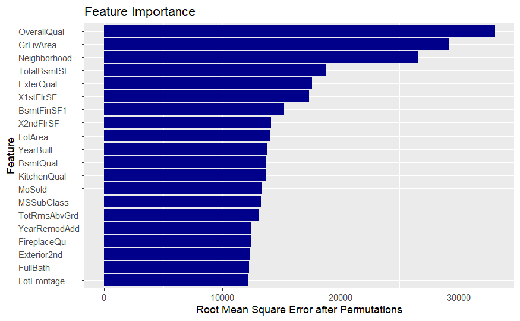

```r
top$variable <- reorder(top$variable, top$dropout_loss)
# Create a bar plot of mean_dropout_loss for each variable
ggplot(top, aes(y = variable, x = dropout_loss, fill = label)) +
  geom_bar(stat = "identity") +
  labs(title = "Feature Importance", y = "Feature", x = "Root Mean Square Error after Permutations") +
  theme(axis.text.y = element_text(hjust = 0), legend.position='None') +
  scale_fill_manual(values = c("randomForest" = "darkblue"))
```

These are the top 20 most important variables according to our Permutation Importance Analysis. OverallQual, GrLivArea, and Neighborhood seem to have a higher impact than the other variables.

## Feature Engineering

### Create New TotalBath Feature

We try to combine the types of bathrooms into total number of bathrooms. We will count half-baths as 0.5.

```r
all$TotalBath <- all$FullBath + (all$HalfBath*0.5) + all$BsmtFullBath + (all$BsmtHalfBath*0.5)
```

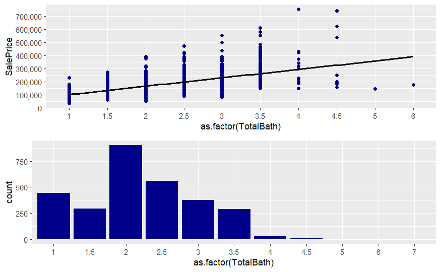

```r
tb1 <- ggplot(data=all[!is.na(all$SalePrice),], aes(x=as.factor(TotalBath), y=SalePrice))+
        geom_point(col='darkblue') + geom_smooth(method = "lm", se=FALSE, color="black", aes(group=1)) +
        scale_y_continuous(breaks= seq(0, 800000, by=100000), labels = comma)
tb2 <- ggplot(data=all, aes(x=as.factor(TotalBath))) +
        geom_histogram(stat='count', fill='darkblue')
grid.arrange(tb1, tb2)
```

We see that there is a correlation between SalePrice and TotalBaths.

```r
correlation_baths <- cor(all[,c('SalePrice','TotalBath')], use="pairwise.complete.obs")
print(correlation_baths)
```

```
          SalePrice TotalBath
SalePrice 1.0000000 0.6317311
TotalBath 0.6317311 1.0000000
```

The correlation is 0.63 - stronger than the previous feature of FullBath at 0.56.

### HouseAge and Remodel

We will calculate the HouseAge from YearRemodAdd and YearSold. Note that YearRemodAdd defaults to YearBlt if there were no remodeling done to the home. Remodel variable will be added to note whether the home was remodeled.

```r
all$Remod <- ifelse(all$YearBuilt==all$YearRemodAdd, 0, 1) #0=No Remodeling, 1=Remodeling
all$Age <- as.numeric(all$YrSold)-all$YearRemodAdd
```

```r
cor_age <- cor(all[,c('SalePrice','Age')], use="pairwise.complete.obs")
print(cor_age)
```

```
           SalePrice        Age
SalePrice  1.0000000 -0.5090787
Age       -0.5090787  1.0000000
```

Higher Age has a negative correlation to SalePrice.

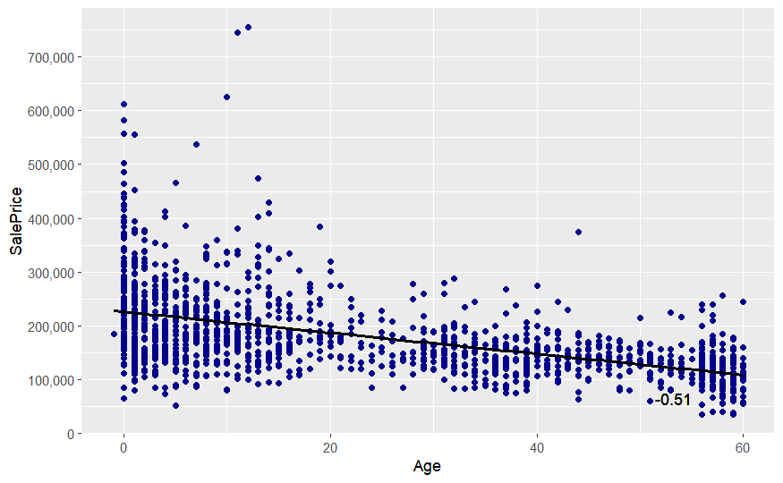

```r
ggplot(data=all[!is.na(all$SalePrice),], aes(x=Age, y=SalePrice))+
        geom_point(col='darkblue') + geom_smooth(method = "lm", se=FALSE, color="black", aes(group=1)) +
        scale_y_continuous(breaks= seq(0, 800000, by=100000), labels = comma) +
        annotate("text", x = 55, y = 65000,
           label = paste(round(cor_age, 2)),
           hjust = 1)  # Adjust text position
```

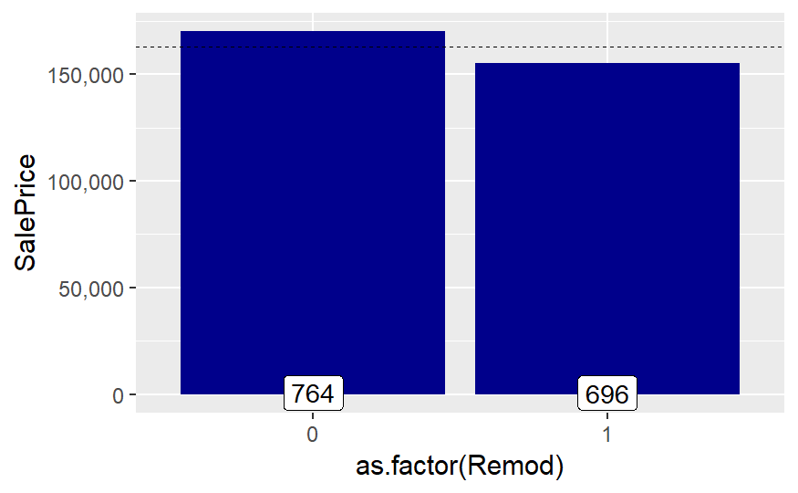

```r
ggplot(all[!is.na(all$SalePrice),], aes(x=as.factor(Remod), y=SalePrice)) +
        geom_bar(stat='summary', fun = "median", fill='darkblue') +
        geom_label(stat = "count", aes(label = ..count.., y = ..count..), size=6) +
        scale_y_continuous(breaks= seq(0, 800000, by=50000), labels = comma) +
        theme_grey(base_size = 18) +
        geom_hline(yintercept=163000, linetype="dashed") #dashed line is median SalePrice
```

Remodeled homes sell for less than homes that haven’t undergone remodeling.

```r
all$IsNew <- ifelse(all$YrSold==all$YearBuilt, 1, 0)
```

We create a new variable for new homes - homes sold same year as they were built.

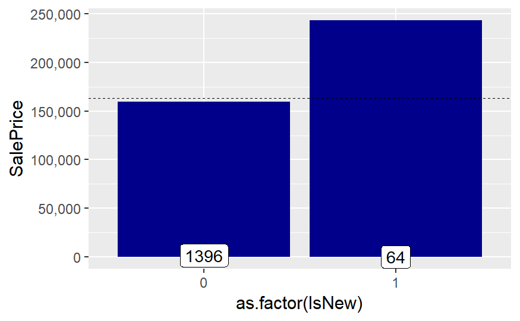

```r
ggplot(all[!is.na(all$SalePrice),], aes(x=as.factor(IsNew), y=SalePrice)) +
        geom_bar(stat='summary', fun = "median", fill='darkblue') +
        geom_label(stat = "count", aes(label = ..count.., y = ..count..), size=6) +
        scale_y_continuous(breaks= seq(0, 800000, by=50000), labels = comma) +
        theme_grey(base_size = 18) +
        geom_hline(yintercept=163000, linetype="dashed") #dashed line is median SalePrice
```

```r
all$YrSold <- as.factor(all$YrSold) #Convert to factor
```

### Neighborhood Feature

There are quite a number of different neighborhoods.

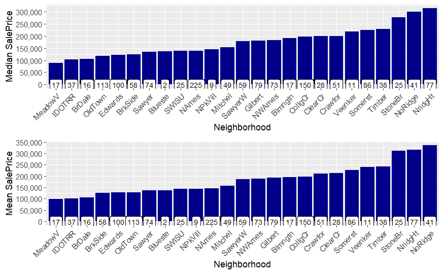

```r
nb1 <- ggplot(all[!is.na(all$SalePrice),], aes(x=reorder(Neighborhood, SalePrice, FUN=median), y=SalePrice)) +
        geom_bar(stat='summary', fun = "median", fill='darkblue') + labs(x='Neighborhood', y='Median SalePrice') +
        theme(axis.text.x = element_text(angle = 45, hjust = 1)) +
        scale_y_continuous(breaks= seq(0, 800000, by=50000), labels = comma) +
        geom_label(stat = "count", aes(label = ..count.., y = ..count..), size=3)
nb2 <- ggplot(all[!is.na(all$SalePrice),], aes(x=reorder(Neighborhood, SalePrice, FUN=mean), y=SalePrice)) +
        geom_bar(stat='summary', fun = "mean", fill='darkblue') + labs(x='Neighborhood', y="Mean SalePrice") +
        theme(axis.text.x = element_text(angle = 45, hjust = 1)) +
        scale_y_continuous(breaks= seq(0, 800000, by=50000), labels = comma) +
        geom_label(stat = "count", aes(label = ..count.., y = ..count..), size=3)
grid.arrange(nb1, nb2)
```

We will create 3 total bins for Neighborhood.

```r
all$NeighRich[all$Neighborhood %in% c('StoneBr', 'NridgHt', 'NoRidge')] <- 2 # Higher SalePrice
all$NeighRich[!all$Neighborhood %in% c('MeadowV', 'IDOTRR', 'BrDale', 'StoneBr', 'NridgHt', 'NoRidge')] <- 1
all$NeighRich[all$Neighborhood %in% c('MeadowV', 'IDOTRR', 'BrDale')] <- 0 # Lower SalePrice

table(all$NeighRich)
```

```
   0    1    2
 160 2471  288
```

### Total Square Feet Feature

Let’s combine basement area with area above ground.

```r
all$TotalSqFeet <- all$GrLivArea + all$TotalBsmtSF
```

```r
cor(all$SalePrice, all$TotalSqFeet, use= "pairwise.complete.obs")
```

```
[1] 0.7789588
```

This has improved our correlation with SalePrice (0.71 > 0.78).

## Data Preparation for Model

### Dropping features with high correlation

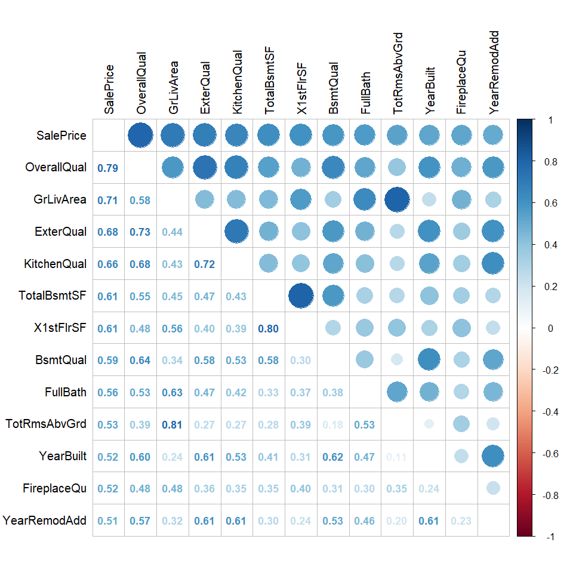

```r
corrplot.mixed(cor_numVar, tl.col="black", tl.pos = "lt", number.cex=0.9)
```

```r
dropVars <- c('YearRemodAdd', 'YearBuilt','GarageArea', 'GarageType', 'GarageCars','FullBath','X1stFlrSF','TotalBsmtSF','GrLivArea','GarageYrBlt')

all <- all[,!(names(all) %in% dropVars)]
```

### Predictor Variable Processing

```r
numericVarNames <- numericVarNames[!(numericVarNames %in% c('MSSubClass', 'MoSold', 'YrSold', 'SalePrice', 'OverallQual', 'OverallCond'))]
numericVarNames <- append(numericVarNames, c('Age', 'TotalBath', 'TotalSqFeet'))
```

```r
DFnumeric <- all[, names(all) %in% numericVarNames]

DFfactors <- all[, !(names(all) %in% numericVarNames)]
DFfactors <- DFfactors[, names(DFfactors) != 'SalePrice']

cat('There are', length(DFnumeric), 'numeric variables, and', length(DFfactors), 'factor variables')
```

```
There are 25 numeric variables, and 49 factor variables
```

#### Skew

A few of the features have quite a bit of right skew. We take the log + 1 for features with skew > 0.8.

```r
for(i in 1:ncol(DFnumeric)){
        if (abs(skew(DFnumeric[,i]))>0.8){
                DFnumeric[,i] <- log(DFnumeric[,i] +1)
        }
}
```

#### Normalize Data

```r
PreNum <- preProcess(DFnumeric, method=c("center", "scale"))
print(PreNum)
```

```
Created from 2919 samples and 25 variables

Pre-processing:
  - centered (25)
  - ignored (0)
  - scaled (25)
```

```r
DFnorm <- predict(PreNum, DFnumeric)
dim(DFnorm)
```

```
[1] 2919   25
```

#### One-hot encode categorical data

```r
DFdummies <- as.data.frame(model.matrix(~.-1, DFfactors))
dim(DFdummies)
```

```
[1] 2919  196
```

```r
combined <- cbind(DFnorm, DFdummies)
```

### Target Skew

```r
skew(all$SalePrice)
```

```
[1] 1.879009
```

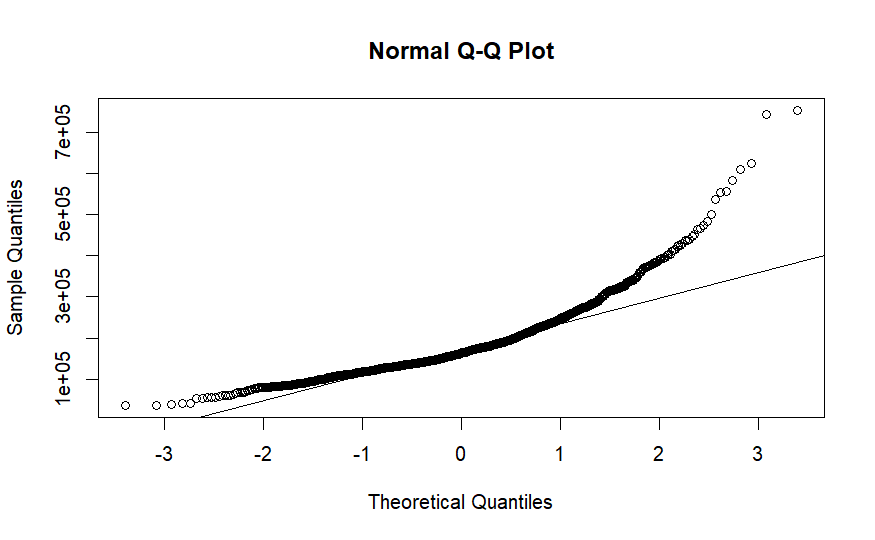

```r
qqnorm(all$SalePrice)
qqline(all$SalePrice)
```

Let’s take log of SalePrice to fix the skew.

```r
all$SalePrice <- log(all$SalePrice) #default is the natural logarithm, "+1" is not necessary as there are no 0's
skew(all$SalePrice)
```

```
[1] 0.1210859
```

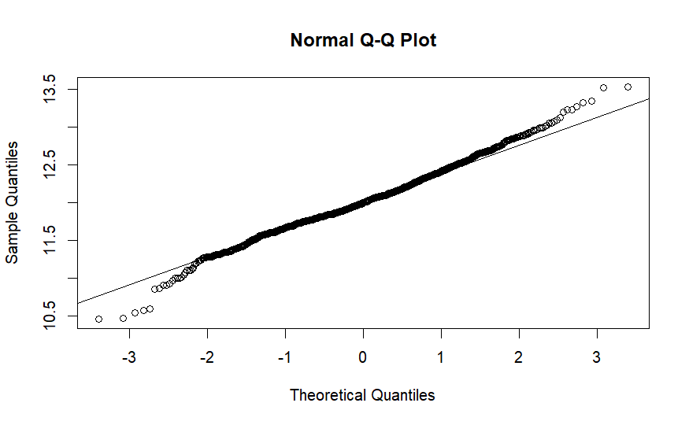

```r
qqnorm(all$SalePrice)
qqline(all$SalePrice)
```

```r
train1 <- combined[!is.na(all$SalePrice),]
test1 <- combined[is.na(all$SalePrice),]
```

## Lasso Regression Model

We find the best lambda for the lasso regression model.

```r
set.seed(27042018)
my_control <-trainControl(method="cv", number=5)
lassoGrid <- expand.grid(alpha = 1, lambda = seq(0.001,0.1,by = 0.0005))

lasso_mod <- train(x=train1, y=all$SalePrice[!is.na(all$SalePrice)], method='glmnet', trControl= my_control, tuneGrid=lassoGrid)
lasso_mod$bestTune
```

|  | alpha | lambda |
| --- | --- | --- |
| 9 | 1 | 0.005 |

```r
min(lasso_mod$results$RMSE)
```

```
[1] 0.1348757
```

Then, we assess how many features eliminated.

```r
lassoVarImp <- varImp(lasso_mod,scale=F)
lassoImportance <- lassoVarImp$importance

varsSelected <- length(which(lassoImportance$Overall!=0))
varsNotSelected <- length(which(lassoImportance$Overall==0))

cat('Lasso uses', varsSelected, 'variables in its model, and did not select', varsNotSelected, 'variables.')
```

```
Lasso uses 66 variables in its model, and did not select 155 variables.
```

Generate the predictions.

```r
LassoPred <- predict(lasso_mod, test1)
predictions_lasso <- exp(LassoPred) #need to reverse the log to the real values
head(predictions_lasso)
```

```
    1461     1462     1463     1464     1465     1466
117203.5 164318.4 172326.0 195111.8 209312.7 169476.7
```

## XGBoost Model

Cross-Validation Parameters

```r
xgb_grid = expand.grid(
nrounds = 1000,
eta = c(0.1, 0.05, 0.01),
max_depth = c(2, 3, 4, 5, 6),
gamma = 0,
colsample_bytree=1,
min_child_weight=c(1, 2, 3, 4 ,5),
subsample=1
)
```

```r
xgb_caret <- train(x=train1, y=all$SalePrice[!is.na(all$SalePrice)], method='xgbTree', trControl= my_control, tuneGrid=xgb_grid)
xgb_caret$bestTune
```

|  | nrounds | max_depth | eta | gamma | colsample_bytree | min_child_weight | subsample |
| --- | --- | --- | --- | --- | --- | --- | --- |
| 45 | 1000 | 5 | 0.05 | 0 | 1 | 5 | 1 |

```r
label_train <- all$SalePrice[!is.na(all$SalePrice)]

# put our testing & training data into two seperates Dmatrixs objects
dtrain <- xgb.DMatrix(data = as.matrix(train1), label= label_train)
dtest <- xgb.DMatrix(data = as.matrix(test1))
```

Parameters based on best-tuned from caret CV.

```r
default_param<-list(
        objective = "reg:squarederror",
        booster = "gbtree",
        eta=0.05, #default = 0.3
        gamma=0,
        max_depth=5, #default=6
        min_child_weight=5, #default=1
        subsample=1,
        colsample_bytree=1
)
```

Check for ‘best’ nrounds.

```r
xgbcv <- xgb.cv( params = default_param, data = dtrain, nrounds = 500, nfold = 5, showsd = T, stratified = T, print_every_n = 40, early_stopping_rounds = 10, maximize = F)
```

[output not shown]

nrounds = 275

```r
xgb_mod <- xgb.train(data = dtrain, params=default_param, nrounds = 275)
XGBpred <- predict(xgb_mod, dtest)
predictions_XGB <- exp(XGBpred) #need to reverse the log to the real values
head(predictions_XGB)
```

```
[1] 117648.9 169557.9 184565.0 183881.4 186405.6 165754.6
```

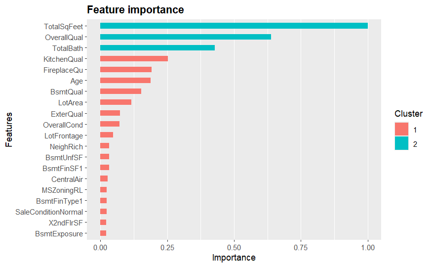

```r
library(Ckmeans.1d.dp) #required for ggplot clustering
mat <- xgb.importance (feature_names = colnames(train1),model = xgb_mod)
xgb.ggplot.importance(importance_matrix = mat[1:20], rel_to_first = TRUE)
```

## Average Predictions

```r
sub_avg <- data.frame(SalePrice = (predictions_XGB*2+predictions_lasso)/3)
head(sub_avg)
```

|  | SalePrice |
| --- | --- |
| 1461 | 117500.4 |
| 1462 | 167811.4 |
| 1463 | 180485.4 |
| 1464 | 187624.9 |
| 1465 | 194041.3 |
| 1466 | 166995.3 |